# Understanding Ordinal Logit Model

## Introduction

This page will explain what the cut points are and how to use both the coefficients and the cutpoints from an ordinal logistic regression to generate predicted probabilities. I am spending the time to make this page so you can read through it at your own pace. The explanation will go as slowly as possible. I do not expect you to understand everything in one setting. However, I do expect you to read through it and do your best to understand everything before our next Zoom meeting. My belief is that you **can** understand it. Just so we have something “fun” to keep ourselves occupied, I list three challengs at the end of this page.

## Some Preparation

To start, it’s useful to review the relationship between probability and logged odds.We are going to start with some mathematical equations but I **promise** that you can follow them. Here are what we already know:

$$\begin{equation}
Odds=\frac{P}{1-P}
\tag{1}
\end{equation}$$

$$\begin{equation}
\log(Odds)=\log{(\frac{P}{1-P})}
\tag{2}
\end{equation}$$

At this point, you should be familiar with how $log$ works, we can transform *Equation (2)* to:

$$\begin{equation}
\log(Odds)=\log(P)-\log(1-P)
\tag{3}
\end{equation}$$

With this in mind, let’s imagine a variable with two states, or categories, $A$ and $B$. Naturally:

$$\begin{equation}
P_{A}+P_{B}=1
\tag{4}
\end{equation}$$

Now, based on Equation (3),

$$\begin{equation}
\log(Odds_{A})+log(Odds_{B})=\{\log( P_{A})-\log(1- P_{A})\}+\{\log( P_{B})-\log(1- P_{B})\}
\tag{5}
\end{equation}$$

Based on *Equation (4)*, we know $log(Odds_{A})+log(Odds_{B})$ will add up to 0:

$$\begin{equation}
\log(Odds_{A})+log(Odds_{B})=\{\log( P_{A})-\log(P_{B})\}+\{\log( P_{B})-\log(P_{A})\}=0
\tag{6}
\end{equation}$$

To visualize *Equation (4)* and *Equation (6)*:

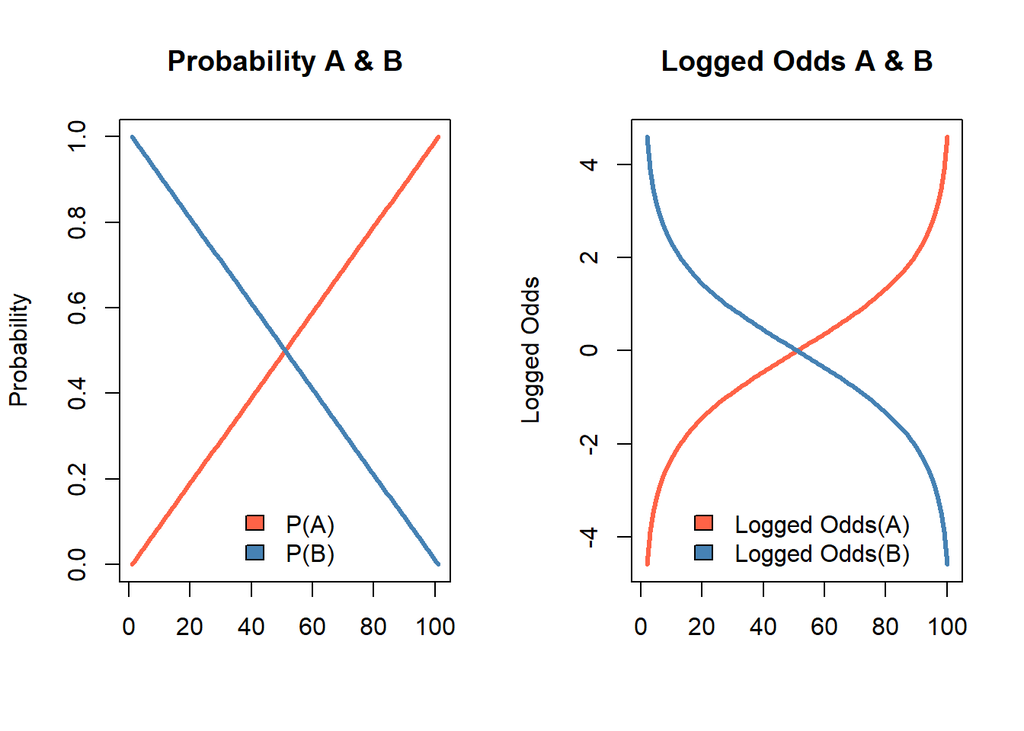

In sum, **the probabilities of the two categories will add up to 1 and the logged odds of the two categories will add up to 0.** If you think everything makes sense, you’re ready for the next section.

## Cut points

Okay, now let’s go back to the example we have in class. You do not need to understand the syntax since I am writing everying in R. Just read what you can. I am doing my best to make it readable.

- First, I will be loading the data set and tabulate the “demo” variable we used in class:

```r
library(foreign)
library(MASS)
setwd("C:/Users/kenho/OneDrive/Teaching/Regression Analysis/Data")
data<-read.dta("wrkdat92_08_r.dta")
# Remember we constructed this variable called "demo"?
data$demo<-as.factor(data$demo)
data$demo<-ordered(data$demo,levels=1:3,labels=c("Republican","Independent","Democrat"))
prop.table(table(data$demo))
```

```
##
##  Republican Independent    Democrat
##   0.2486749   0.3923537   0.3589715
```

- This is showing us that 24.9 % of our observations are in the first category,39.2% in the second category, 35.9% in the third category.
- Now I am estimating an ordinal logistic regression without any independent variable in the model:

```r
ol<-polr(demo~1,data=data,Hess=F)
summary(ol)
```

```
##
## Re-fitting to get Hessian
```

```
## Call:
## polr(formula = demo ~ 1, data = data, Hess = F)
##
## No coefficients
##
## Intercepts:
##                        Value    Std. Error t value
## Republican|Independent  -1.1056   0.0246   -45.0024
## Independent|Democrat     0.5798   0.0221    26.1905
##
## Residual Deviance: 19168.89
## AIC: 19172.89
```

- Like with STATA, we are getting two cut points. The first one is -1.1056 and the second one is 0.5798. These are **logged odds**. We can translate them to probabilities with the equation in our slides:

$$\begin{equation}
P=\frac{Odds}{1+Odds}
\tag{7}
\end{equation}$$

- Remember this equation since we will be using it again and again to transform (logged) odds into probabilities. Put this equation into action:

```r
cutpoint1<-ol$zeta[1]
cutpoint2<-ol$zeta[2]
cutpoint1_p<-exp(cutpoint1)/(1+exp(cutpoint1))
cutpoint2_p<-exp(cutpoint2)/(1+exp(cutpoint2))
print(cutpoint1_p)
```

```
## Republican|Independent
##               0.248685
```

```r
print(cutpoint2_p)
```

```
## Independent|Democrat
##            0.6410243
```

- Recall the above table:

```r
prop.table(table(data$demo))
```

```
##
##  Republican Independent    Democrat
##   0.2486749   0.3923537   0.3589715
```

- Clearly, the first cut point is giving us the cumulative probability of being below the second category and the second cut point is giving us the probability of being below the third category. Visually speaking:

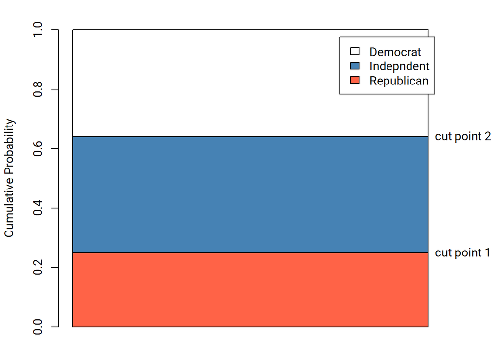

```r
windowsFonts(A = windowsFont("Roboto"))
par(family="A",mar=c(2, 4, 2, 4) + 0.1)
bar<-matrix(c(cutpoint1_p,cutpoint2_p-cutpoint1_p,1-cutpoint2_p),ncol=1)
barplot(bar,beside=F,ylim=c(0,1),ylab="Cumulative Probability",legend.text = c("Republican","Indepndent","Democrat"),
        col=c(cpal,"white"))
text(1.3,cutpoint1_p,"cut point 1",xpd=TRUE)
text(1.3,cutpoint2_p,"cut point 2",xpd=TRUE)
```

Now, you understand what these cut points represent when we don’t have any regressor in the model.

**Since the logged odds of being above and the logged odds of being below will add up to 0**. You know the logged odds of being above the first category will be 0-cut point 1, and, of course, the logged odds of being above the second category will be 0-cut point 2. You may want to go back to make sure you fully understand why. Let’s see if this is true:

```r
above1_lo<-(0-cutpoint1) # The logged odds of being above the first category
above2_lo<-(0-cutpoint2) # The logged odds of being above the second category

#Transform the logged odds to probabilities:
above1_p<-exp(above1_lo)/(1+exp(above1_lo))
above2_p<-exp(above2_lo)/(1+exp(above2_lo))
print(above1_p)
```

```
## Republican|Independent
##               0.751315
```

```r
print(above2_p)
```

```
## Independent|Democrat
##            0.3589757
```

*Voila!* We are right! These probabilities are the blue+white area and the white area respectively. Nothing can stop us now!

## Cut points + Coefficients

It’s time for us to bring race back into the picture. Let’s first estimate the model:

```r
olrace<-polr(demo~race2,data=data,Hess=F)
summary(olrace)
```

```
##
## Re-fitting to get Hessian
```

```
## Call:
## polr(formula = demo ~ race2, data = data, Hess = F)
##
## Coefficients:
##              Value Std. Error t value
## race2Black  1.2528    0.05849  21.417
## race2Latino 0.7053    0.06593  10.698
## race2Other  0.1564    0.08295   1.886
##
## Intercepts:
##                        Value    Std. Error t value
## Republican|Independent  -0.8772   0.0273   -32.1391
## Independent|Democrat     0.8869   0.0273    32.4435
##
## Residual Deviance: 18627.49
## AIC: 18637.49
```

- Okay, we have White as our reference group, and the coefficients for Black, Latino, and Other respectively. We also have two cut points. It appears that all non-White groups are more likely to be on a higher category in contrast to a lower category. Let’s focus on the two cut points first. They are about the reference group: White.

```r
whitecut1<-olrace$zeta[1]
whitecut2<-olrace$zeta[2]
whitecut1_p<-exp(whitecut1)/(1+exp(whitecut1))
whitecut2_p<-exp(whitecut2)/(1+exp(whitecut2))
print(whitecut1_p)
```

```
## Republican|Independent
##              0.2937604
```

```r
print(whitecut2_p)
```

```
## Independent|Democrat
##            0.7082525
```

- These two cut points are telling us that the predicted probability of White being in the first category (Republican) is 0.2937604 and the predicted probability of white being in the first **and** the second categories is 0.7082525. Based on the discussion in the previous two sections, you also know that the **logged odds** of White being above the first category is simply 0.8772 and the logged odds of being above the second category is simply -0.8869.
- These numbers are not identical to the actual numbers because of the assumptions made by the model but in this case they are fairly close.These are the numbers you would get when you use the **margins** command in STATA.
- Now, we want to know the probability of Blacks being a Republican. To do so, what we will do is to first figure out the probability of Blacks being **above** Republican. The logged odds of Blacks not being Republican will be:

$$\begin{equation}
log(Odds_{Black>1})=(0-cut point 1)+1.2528
\tag{8}
\end{equation}$$

- In not so plain English: **The logged Odds of Blacks being above the first category** equals to **the logged odds of Whites being above the first category** plus **the coefficient for Blacks**. As you can see here, the coefficient is adjusting the cut point.

```r
black_above1_lo<-0-whitecut1+1.2528
print(black_above1_lo)
```

```
## Republican|Independent
##                2.12999
```

- Once we figure this out, we can easily calculate the predicted probabily of Blacks in the first category since all probabilities add up to 1.

```r
black_above1_p<-exp(black_above1_lo)/(1+exp(black_above1_lo))# Calculate the probability of Blacks being above 1
black_1_p<-1-black_above1_p # Calculate the probabilty of Blacks being Repbulican
print(black_1_p)
```

```
## Republican|Independent
##              0.1062159
```

- This is the number you would get when you use the **margins** command in STATA for Blacks when **predict(outcome(1))**. Alright we’re getting to the end. Be patient with me. How do we figure out the predicted probability of Blacks being in the second category?
- Well, we can first do what we just did in *Equation (8)*. This time, we calculate the predicted logged odds of Blacks being above the second category

$$\begin{equation}
log(Odds_{Black>2})=(0-cut point 2)+1.2528
\tag{9}
\end{equation}$$

- Again, this equation is saying: **The logged Odds of Blacks being above the second category** equals to **the logged odds of Whites being above the second category** plus **the coefficient for Blacks**. Notice that we are using the second cut point this time.

```r
black_above2_lo<-0-whitecut2+1.2528
black_above2_p<-exp(black_above2_lo)/(1+exp(black_above2_lo))
print(black_above2_p)
```

```
## Independent|Democrat
##             0.590465
```

- This is the predicted probability of Blacks being above Independent, which is essentially the predicted probability of being Democrat. Naturally, the probability of Blacks being either Independent or Republican would be:

```r
black_12_p<-1-black_above2_p
print(black_12_p)
```

```
## Independent|Democrat
##             0.409535
```

- and the probability of Blacks being in the second category would be the difference between this number and the predicted probability of Blacks being Republican:

```r
black_2_p<-black_12_p-black_1_p
print(black_2_p)
```

```
## Independent|Democrat
##            0.3033191
```

- This is the number you would get when you use the **margins** command in STATA for Blacks when **predict(outcome(2))**
- In this process, we also know the predicted probability of Blacks being Democrat.

**Congrats!!** Know you have a pretty in-depth understanding of how an ordinal logistic regression works. You probably know more than 95% of the graduate students in sociology who have learned about ordinal logistic regression, I would guess, since cut points are rarely discussed technically.

## Challenges

Now, please go back and predict following probabilities based on the estimates above:

1. Whites being Democrat
2. Latino being Republican
3. Other being Independent